# Risk Factor Analysis

## Outcome Variable

**Outcome Variable:** ever_stunted

## Predictor Variables

**Intervention Variable:** impfloor

**Adjustment Set:**

- arm
- sex
- W_mage
- meducyrs
- feducyrs
- hhwealth_quart
- hfoodsec
- W_mhtcm
- W_mwtkg
- W_mbmi
- W_nrooms
- W_nchldlt5
- W_parity
- impsan
- safeh20
- delta_W_mage
- delta_meducyrs
- delta_feducyrs
- delta_hhwealth_quart
- delta_hfoodsec
- delta_W_mhtcm
- delta_W_mwtkg
- delta_W_mbmi
- delta_W_nrooms
- delta_W_nchldlt5
- delta_W_parity
- delta_impsan
- delta_safeh20

## Stratifying Variables

The analysis was stratified on these variable(s):

- agecat
- studyid
- country

## Data Summary

| agecat | studyid | country | impfloor | ever_stunted | n_cell | n |
| --- | --- | --- | --- | --- | --- | --- |
| 0-24 months (no birth st.) | CMC-V-BCS-2002 | INDIA | 1 | 0 | 21 | 198 |
| 0-24 months (no birth st.) | CMC-V-BCS-2002 | INDIA | 1 | 1 | 177 | 198 |
| 0-24 months (no birth st.) | CMC-V-BCS-2002 | INDIA | 0 | 0 | 0 | 198 |
| 0-24 months (no birth st.) | CMC-V-BCS-2002 | INDIA | 0 | 1 | 0 | 198 |
| 0-24 months (no birth st.) | CONTENT | PERU | 1 | 0 | 150 | 195 |
| 0-24 months (no birth st.) | CONTENT | PERU | 1 | 1 | 32 | 195 |
| 0-24 months (no birth st.) | CONTENT | PERU | 0 | 0 | 12 | 195 |
| 0-24 months (no birth st.) | CONTENT | PERU | 0 | 1 | 1 | 195 |
| 0-24 months (no birth st.) | GMS-Nepal | NEPAL | 1 | 0 | 50 | 453 |
| 0-24 months (no birth st.) | GMS-Nepal | NEPAL | 1 | 1 | 42 | 453 |
| 0-24 months (no birth st.) | GMS-Nepal | NEPAL | 0 | 0 | 148 | 453 |
| 0-24 months (no birth st.) | GMS-Nepal | NEPAL | 0 | 1 | 213 | 453 |
| 0-24 months (no birth st.) | IRC | INDIA | 1 | 0 | 123 | 270 |
| 0-24 months (no birth st.) | IRC | INDIA | 1 | 1 | 147 | 270 |
| 0-24 months (no birth st.) | IRC | INDIA | 0 | 0 | 0 | 270 |
| 0-24 months (no birth st.) | IRC | INDIA | 0 | 1 | 0 | 270 |
| 0-24 months (no birth st.) | JiVitA-3 | BANGLADESH | 1 | 0 | 1375 | 18325 |
| 0-24 months (no birth st.) | JiVitA-3 | BANGLADESH | 1 | 1 | 279 | 18325 |
| 0-24 months (no birth st.) | JiVitA-3 | BANGLADESH | 0 | 0 | 12329 | 18325 |
| 0-24 months (no birth st.) | JiVitA-3 | BANGLADESH | 0 | 1 | 4342 | 18325 |
| 0-24 months (no birth st.) | JiVitA-4 | BANGLADESH | 1 | 0 | 361 | 3874 |
| 0-24 months (no birth st.) | JiVitA-4 | BANGLADESH | 1 | 1 | 154 | 3874 |
| 0-24 months (no birth st.) | JiVitA-4 | BANGLADESH | 0 | 0 | 1908 | 3874 |
| 0-24 months (no birth st.) | JiVitA-4 | BANGLADESH | 0 | 1 | 1451 | 3874 |
| 0-24 months (no birth st.) | MAL-ED | BANGLADESH | 1 | 0 | 85 | 203 |
| 0-24 months (no birth st.) | MAL-ED | BANGLADESH | 1 | 1 | 101 | 203 |
| 0-24 months (no birth st.) | MAL-ED | BANGLADESH | 0 | 0 | 8 | 203 |
| 0-24 months (no birth st.) | MAL-ED | BANGLADESH | 0 | 1 | 9 | 203 |
| 0-24 months (no birth st.) | MAL-ED | BRAZIL | 1 | 0 | 152 | 185 |
| 0-24 months (no birth st.) | MAL-ED | BRAZIL | 1 | 1 | 31 | 185 |

[output cut: 98 more lines]

The following strata were considered:

- agecat: 0-24 months (no birth st.), studyid: CMC-V-BCS-2002, country: INDIA
- agecat: 0-24 months (no birth st.), studyid: CONTENT, country: PERU
- agecat: 0-24 months (no birth st.), studyid: GMS-Nepal, country: NEPAL
- agecat: 0-24 months (no birth st.), studyid: IRC, country: INDIA
- agecat: 0-24 months (no birth st.), studyid: JiVitA-3, country: BANGLADESH
- agecat: 0-24 months (no birth st.), studyid: JiVitA-4, country: BANGLADESH
- agecat: 0-24 months (no birth st.), studyid: MAL-ED, country: BANGLADESH
- agecat: 0-24 months (no birth st.), studyid: MAL-ED, country: BRAZIL
- agecat: 0-24 months (no birth st.), studyid: MAL-ED, country: INDIA
- agecat: 0-24 months (no birth st.), studyid: MAL-ED, country: NEPAL
- agecat: 0-24 months (no birth st.), studyid: MAL-ED, country: PERU
- agecat: 0-24 months (no birth st.), studyid: MAL-ED, country: SOUTH AFRICA
- agecat: 0-24 months (no birth st.), studyid: MAL-ED, country: TANZANIA, UNITED REPUBLIC OF
- agecat: 0-24 months (no birth st.), studyid: NIH-Birth, country: BANGLADESH
- agecat: 0-24 months (no birth st.), studyid: NIH-Crypto, country: BANGLADESH
- agecat: 0-24 months (no birth st.), studyid: PROVIDE, country: BANGLADESH
- agecat: 0-6 months (no birth st.), studyid: CMC-V-BCS-2002, country: INDIA
- agecat: 0-6 months (no birth st.), studyid: CONTENT, country: PERU
- agecat: 0-6 months (no birth st.), studyid: GMS-Nepal, country: NEPAL
- agecat: 0-6 months (no birth st.), studyid: IRC, country: INDIA
- agecat: 0-6 months (no birth st.), studyid: JiVitA-3, country: BANGLADESH
- agecat: 0-6 months (no birth st.), studyid: JiVitA-4, country: BANGLADESH
- agecat: 0-6 months (no birth st.), studyid: MAL-ED, country: BANGLADESH
- agecat: 0-6 months (no birth st.), studyid: MAL-ED, country: BRAZIL
- agecat: 0-6 months (no birth st.), studyid: MAL-ED, country: INDIA
- agecat: 0-6 months (no birth st.), studyid: MAL-ED, country: NEPAL
- agecat: 0-6 months (no birth st.), studyid: MAL-ED, country: PERU
- agecat: 0-6 months (no birth st.), studyid: MAL-ED, country: SOUTH AFRICA
- agecat: 0-6 months (no birth st.), studyid: MAL-ED, country: TANZANIA, UNITED REPUBLIC OF
- agecat: 0-6 months (no birth st.), studyid: NIH-Birth, country: BANGLADESH
- agecat: 0-6 months (no birth st.), studyid: NIH-Crypto, country: BANGLADESH
- agecat: 0-6 months (no birth st.), studyid: PROVIDE, country: BANGLADESH

### Dropped Strata

Some strata were dropped due to rare outcomes:

- agecat: 0-24 months (no birth st.), studyid: CMC-V-BCS-2002, country: INDIA
- agecat: 0-24 months (no birth st.), studyid: CONTENT, country: PERU
- agecat: 0-24 months (no birth st.), studyid: IRC, country: INDIA
- agecat: 0-24 months (no birth st.), studyid: MAL-ED, country: BRAZIL
- agecat: 0-24 months (no birth st.), studyid: MAL-ED, country: INDIA
- agecat: 0-24 months (no birth st.), studyid: MAL-ED, country: TANZANIA, UNITED REPUBLIC OF
- agecat: 0-6 months (no birth st.), studyid: CMC-V-BCS-2002, country: INDIA
- agecat: 0-6 months (no birth st.), studyid: CONTENT, country: PERU
- agecat: 0-6 months (no birth st.), studyid: IRC, country: INDIA
- agecat: 0-6 months (no birth st.), studyid: MAL-ED, country: BANGLADESH
- agecat: 0-6 months (no birth st.), studyid: MAL-ED, country: BRAZIL
- agecat: 0-6 months (no birth st.), studyid: MAL-ED, country: INDIA
- agecat: 0-6 months (no birth st.), studyid: MAL-ED, country: NEPAL
- agecat: 0-6 months (no birth st.), studyid: MAL-ED, country: TANZANIA, UNITED REPUBLIC OF

## Methods Detail

We're interested in the causal parameters $E[Y_a]$ for all values of $a \in \mathcal{A}$. These parameters represent the mean outcome if, possibly contrary to fact, we intervened to set all units to have $A=a$. Under the randomization and positivity assumptions, these are identified by the statistical parameters $\psi_a=E_W[E_{Y|A,W}(Y|A=a,W)]$. In addition, we're interested in the mean of $Y$, $E[Y]$ under no intervention (the observed mean). We will estimate these parameters by using SuperLearner to fit the relevant likelihood factors -- $E_{Y|A,W}(Y|A=a,W)$ and $p(A=a|W)$, and then updating our likelihood fit using a joint TMLE.

For unadjusted analyses ($W=\{\}$), initial likelihoods were estimated using Lrnr_glm to estimate the simple $E(Y|A)$ and Lrnr_mean to estimate $p(A)$. For adjusted analyses, a small library containing Lrnr_glmnet, Lrnr_xgboost, and Lrnr_mean was used.

Having estimated these parameters, we will then use the delta method to estimate relative risks and attributable risks relative to a prespecified baseline level of $A$.

# Results Detail

## Results Plots

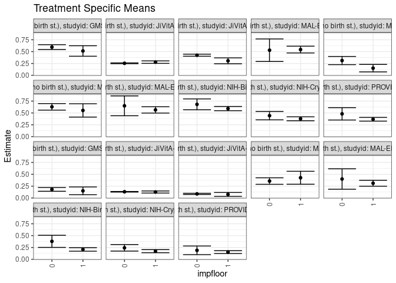

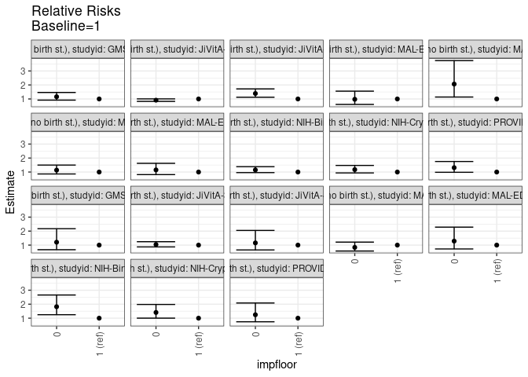

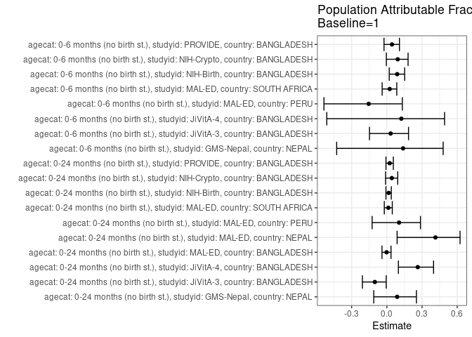

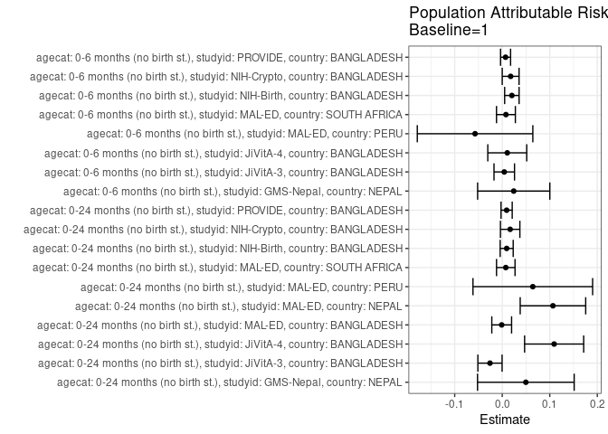

## Results Table

### Parameter: TSM

| agecat | studyid | country | intervention_level | baseline_level | estimate | ci_lower | ci_upper |
| --- | --- | --- | --- | --- | --- | --- | --- |
| 0-24 months (no birth st.) | GMS-Nepal | NEPAL | 1 | NA | 0.5132334 | 0.4022204 | 0.6242464 |
| 0-24 months (no birth st.) | GMS-Nepal | NEPAL | 0 | NA | 0.5950144 | 0.5437557 | 0.6462732 |
| 0-24 months (no birth st.) | JiVitA-3 | BANGLADESH | 1 | NA | 0.2779355 | 0.2520525 | 0.3038184 |
| 0-24 months (no birth st.) | JiVitA-3 | BANGLADESH | 0 | NA | 0.2534694 | 0.2453435 | 0.2615953 |
| 0-24 months (no birth st.) | JiVitA-4 | BANGLADESH | 1 | NA | 0.3051256 | 0.2427059 | 0.3675454 |
| 0-24 months (no birth st.) | JiVitA-4 | BANGLADESH | 0 | NA | 0.4238704 | 0.4024897 | 0.4452511 |
| 0-24 months (no birth st.) | MAL-ED | BANGLADESH | 1 | NA | 0.5430108 | 0.4712444 | 0.6147772 |
| 0-24 months (no birth st.) | MAL-ED | BANGLADESH | 0 | NA | 0.5294118 | 0.2915562 | 0.7672673 |
| 0-24 months (no birth st.) | MAL-ED | NEPAL | 1 | NA | 0.1507466 | 0.0719288 | 0.2295645 |
| 0-24 months (no birth st.) | MAL-ED | NEPAL | 0 | NA | 0.3112388 | 0.2250591 | 0.3974186 |
| 0-24 months (no birth st.) | MAL-ED | PERU | 1 | NA | 0.5533550 | 0.4124644 | 0.6942456 |
| 0-24 months (no birth st.) | MAL-ED | PERU | 0 | NA | 0.6285303 | 0.5596017 | 0.6974589 |
| 0-24 months (no birth st.) | MAL-ED | SOUTH AFRICA | 1 | NA | 0.5645933 | 0.4972273 | 0.6319593 |
| 0-24 months (no birth st.) | MAL-ED | SOUTH AFRICA | 0 | NA | 0.6500000 | 0.4405048 | 0.8594952 |
| 0-24 months (no birth st.) | NIH-Birth | BANGLADESH | 1 | NA | 0.5917935 | 0.5473102 | 0.6362768 |
| 0-24 months (no birth st.) | NIH-Birth | BANGLADESH | 0 | NA | 0.6813742 | 0.5667282 | 0.7960203 |
| 0-24 months (no birth st.) | NIH-Crypto | BANGLADESH | 1 | NA | 0.3768970 | 0.3352140 | 0.4185799 |
| 0-24 months (no birth st.) | NIH-Crypto | BANGLADESH | 0 | NA | 0.4423800 | 0.3537543 | 0.5310056 |
| 0-24 months (no birth st.) | PROVIDE | BANGLADESH | 1 | NA | 0.3667718 | 0.3274719 | 0.4060716 |
| 0-24 months (no birth st.) | PROVIDE | BANGLADESH | 0 | NA | 0.4809086 | 0.3504652 | 0.6113520 |
| 0-6 months (no birth st.) | GMS-Nepal | NEPAL | 1 | NA | 0.1502268 | 0.0681697 | 0.2322838 |
| 0-6 months (no birth st.) | GMS-Nepal | NEPAL | 0 | NA | 0.1814010 | 0.1416589 | 0.2211432 |
| 0-6 months (no birth st.) | JiVitA-3 | BANGLADESH | 1 | NA | 0.1259313 | 0.1039532 | 0.1479093 |
| 0-6 months (no birth st.) | JiVitA-3 | BANGLADESH | 0 | NA | 0.1310306 | 0.1251629 | 0.1368983 |
| 0-6 months (no birth st.) | JiVitA-4 | BANGLADESH | 1 | NA | 0.0748844 | 0.0334679 | 0.1163009 |
| 0-6 months (no birth st.) | JiVitA-4 | BANGLADESH | 0 | NA | 0.0866524 | 0.0742624 | 0.0990425 |
| 0-6 months (no birth st.) | MAL-ED | PERU | 1 | NA | 0.4269137 | 0.2902770 | 0.5635505 |
| 0-6 months (no birth st.) | MAL-ED | PERU | 0 | NA | 0.3572085 | 0.2887308 | 0.4256862 |
| 0-6 months (no birth st.) | MAL-ED | SOUTH AFRICA | 1 | NA | 0.3110048 | 0.2481097 | 0.3738999 |
| 0-6 months (no birth st.) | MAL-ED | SOUTH AFRICA | 0 | NA | 0.4000000 | 0.1848264 | 0.6151736 |
| 0-6 months (no birth st.) | NIH-Birth | BANGLADESH | 1 | NA | 0.2084721 | 0.1718761 | 0.2450681 |
| 0-6 months (no birth st.) | NIH-Birth | BANGLADESH | 0 | NA | 0.3794220 | 0.2517089 | 0.5071351 |
| 0-6 months (no birth st.) | NIH-Crypto | BANGLADESH | 1 | NA | 0.1722095 | 0.1392717 | 0.2051473 |
| 0-6 months (no birth st.) | NIH-Crypto | BANGLADESH | 0 | NA | 0.2426756 | 0.1738600 | 0.3114911 |
| 0-6 months (no birth st.) | PROVIDE | BANGLADESH | 1 | NA | 0.1525421 | 0.1230528 | 0.1820313 |
| 0-6 months (no birth st.) | PROVIDE | BANGLADESH | 0 | NA | 0.1898431 | 0.0985415 | 0.2811447 |

### Parameter: E(Y)

| agecat | studyid | country | intervention_level | baseline_level | estimate | ci_lower | ci_upper |
| --- | --- | --- | --- | --- | --- | --- | --- |
| 0-24 months (no birth st.) | GMS-Nepal | NEPAL | NA | NA | 0.5629139 | 0.5171858 | 0.6086420 |
| 0-24 months (no birth st.) | JiVitA-3 | BANGLADESH | NA | NA | 0.2521692 | 0.2444469 | 0.2598915 |
| 0-24 months (no birth st.) | JiVitA-4 | BANGLADESH | NA | NA | 0.4143005 | 0.3961166 | 0.4324844 |
| 0-24 months (no birth st.) | MAL-ED | BANGLADESH | NA | NA | 0.5418719 | 0.4731628 | 0.6105810 |
| 0-24 months (no birth st.) | MAL-ED | NEPAL | NA | NA | 0.2574257 | 0.1969827 | 0.3178687 |
| 0-24 months (no birth st.) | MAL-ED | PERU | NA | NA | 0.6176471 | 0.5557776 | 0.6795165 |
| 0-24 months (no birth st.) | MAL-ED | SOUTH AFRICA | NA | NA | 0.5720524 | 0.5078289 | 0.6362759 |
| 0-24 months (no birth st.) | NIH-Birth | BANGLADESH | NA | NA | 0.6011342 | 0.5593675 | 0.6429009 |
| 0-24 months (no birth st.) | NIH-Crypto | BANGLADESH | NA | NA | 0.3935681 | 0.3560687 | 0.4310676 |
| 0-24 months (no birth st.) | PROVIDE | BANGLADESH | NA | NA | 0.3759874 | 0.3382238 | 0.4137509 |
| 0-6 months (no birth st.) | GMS-Nepal | NEPAL | NA | NA | 0.1743929 | 0.1394121 | 0.2093738 |
| 0-6 months (no birth st.) | JiVitA-3 | BANGLADESH | NA | NA | 0.1301898 | 0.1246228 | 0.1357568 |
| 0-6 months (no birth st.) | JiVitA-4 | BANGLADESH | NA | NA | 0.0854560 | 0.0740923 | 0.0968198 |
| 0-6 months (no birth st.) | MAL-ED | PERU | NA | NA | 0.3697479 | 0.3082891 | 0.4312067 |
| 0-6 months (no birth st.) | MAL-ED | SOUTH AFRICA | NA | NA | 0.3187773 | 0.2582893 | 0.3792652 |
| 0-6 months (no birth st.) | NIH-Birth | BANGLADESH | NA | NA | 0.2287335 | 0.1929075 | 0.2645595 |
| 0-6 months (no birth st.) | NIH-Crypto | BANGLADESH | NA | NA | 0.1898928 | 0.1597870 | 0.2199986 |
| 0-6 months (no birth st.) | PROVIDE | BANGLADESH | NA | NA | 0.1595577 | 0.1310079 | 0.1881074 |

### Parameter: RR

| agecat | studyid | country | intervention_level | baseline_level | estimate | ci_lower | ci_upper |
| --- | --- | --- | --- | --- | --- | --- | --- |
| 0-24 months (no birth st.) | GMS-Nepal | NEPAL | 1 | 1 | 1.0000000 | 1.0000000 | 1.000000 |
| 0-24 months (no birth st.) | GMS-Nepal | NEPAL | 0 | 1 | 1.1593447 | 0.9177189 | 1.464588 |
| 0-24 months (no birth st.) | JiVitA-3 | BANGLADESH | 1 | 1 | 1.0000000 | 1.0000000 | 1.000000 |
| 0-24 months (no birth st.) | JiVitA-3 | BANGLADESH | 0 | 1 | 0.9119721 | 0.8276117 | 1.004932 |
| 0-24 months (no birth st.) | JiVitA-4 | BANGLADESH | 1 | 1 | 1.0000000 | 1.0000000 | 1.000000 |
| 0-24 months (no birth st.) | JiVitA-4 | BANGLADESH | 0 | 1 | 1.3891668 | 1.1231152 | 1.718242 |
| 0-24 months (no birth st.) | MAL-ED | BANGLADESH | 1 | 1 | 1.0000000 | 1.0000000 | 1.000000 |
| 0-24 months (no birth st.) | MAL-ED | BANGLADESH | 0 | 1 | 0.9749563 | 0.6103754 | 1.557304 |
| 0-24 months (no birth st.) | MAL-ED | NEPAL | 1 | 1 | 1.0000000 | 1.0000000 | 1.000000 |
| 0-24 months (no birth st.) | MAL-ED | NEPAL | 0 | 1 | 2.0646487 | 1.1384461 | 3.744379 |
| 0-24 months (no birth st.) | MAL-ED | PERU | 1 | 1 | 1.0000000 | 1.0000000 | 1.000000 |
| 0-24 months (no birth st.) | MAL-ED | PERU | 0 | 1 | 1.1358537 | 0.8613700 | 1.497804 |
| 0-24 months (no birth st.) | MAL-ED | SOUTH AFRICA | 1 | 1 | 1.0000000 | 1.0000000 | 1.000000 |
| 0-24 months (no birth st.) | MAL-ED | SOUTH AFRICA | 0 | 1 | 1.1512712 | 0.8164327 | 1.623435 |
| 0-24 months (no birth st.) | NIH-Birth | BANGLADESH | 1 | 1 | 1.0000000 | 1.0000000 | 1.000000 |
| 0-24 months (no birth st.) | NIH-Birth | BANGLADESH | 0 | 1 | 1.1513716 | 0.9589275 | 1.382437 |
| 0-24 months (no birth st.) | NIH-Crypto | BANGLADESH | 1 | 1 | 1.0000000 | 1.0000000 | 1.000000 |
| 0-24 months (no birth st.) | NIH-Crypto | BANGLADESH | 0 | 1 | 1.1737425 | 0.9367390 | 1.470710 |
| 0-24 months (no birth st.) | PROVIDE | BANGLADESH | 1 | 1 | 1.0000000 | 1.0000000 | 1.000000 |
| 0-24 months (no birth st.) | PROVIDE | BANGLADESH | 0 | 1 | 1.3111931 | 0.9803980 | 1.753602 |
| 0-6 months (no birth st.) | GMS-Nepal | NEPAL | 1 | 1 | 1.0000000 | 1.0000000 | 1.000000 |
| 0-6 months (no birth st.) | GMS-Nepal | NEPAL | 0 | 1 | 1.2075148 | 0.6705272 | 2.174546 |
| 0-6 months (no birth st.) | JiVitA-3 | BANGLADESH | 1 | 1 | 1.0000000 | 1.0000000 | 1.000000 |
| 0-6 months (no birth st.) | JiVitA-3 | BANGLADESH | 0 | 1 | 1.0404931 | 0.8707195 | 1.243369 |
| 0-6 months (no birth st.) | JiVitA-4 | BANGLADESH | 1 | 1 | 1.0000000 | 1.0000000 | 1.000000 |
| 0-6 months (no birth st.) | JiVitA-4 | BANGLADESH | 0 | 1 | 1.1571493 | 0.6527815 | 2.051214 |
| 0-6 months (no birth st.) | MAL-ED | PERU | 1 | 1 | 1.0000000 | 1.0000000 | 1.000000 |
| 0-6 months (no birth st.) | MAL-ED | PERU | 0 | 1 | 0.8367230 | 0.5767118 | 1.213960 |
| 0-6 months (no birth st.) | MAL-ED | SOUTH AFRICA | 1 | 1 | 1.0000000 | 1.0000000 | 1.000000 |
| 0-6 months (no birth st.) | MAL-ED | SOUTH AFRICA | 0 | 1 | 1.2861538 | 0.7239480 | 2.284959 |
| 0-6 months (no birth st.) | NIH-Birth | BANGLADESH | 1 | 1 | 1.0000000 | 1.0000000 | 1.000000 |
| 0-6 months (no birth st.) | NIH-Birth | BANGLADESH | 0 | 1 | 1.8200134 | 1.2467889 | 2.656784 |
| 0-6 months (no birth st.) | NIH-Crypto | BANGLADESH | 1 | 1 | 1.0000000 | 1.0000000 | 1.000000 |
| 0-6 months (no birth st.) | NIH-Crypto | BANGLADESH | 0 | 1 | 1.4091882 | 1.0018404 | 1.982163 |
| 0-6 months (no birth st.) | PROVIDE | BANGLADESH | 1 | 1 | 1.0000000 | 1.0000000 | 1.000000 |
| 0-6 months (no birth st.) | PROVIDE | BANGLADESH | 0 | 1 | 1.2445295 | 0.7431246 | 2.084245 |

### Parameter: PAR

| agecat | studyid | country | intervention_level | baseline_level | estimate | ci_lower | ci_upper |
| --- | --- | --- | --- | --- | --- | --- | --- |
| 0-24 months (no birth st.) | GMS-Nepal | NEPAL | 1 | NA | 0.0496805 | -0.0519829 | 0.1513438 |
| 0-24 months (no birth st.) | JiVitA-3 | BANGLADESH | 1 | NA | -0.0257663 | -0.0512439 | -0.0002887 |
| 0-24 months (no birth st.) | JiVitA-4 | BANGLADESH | 1 | NA | 0.1091748 | 0.0470330 | 0.1713167 |
| 0-24 months (no birth st.) | MAL-ED | BANGLADESH | 1 | NA | -0.0011388 | -0.0219512 | 0.0196735 |
| 0-24 months (no birth st.) | MAL-ED | NEPAL | 1 | NA | 0.1066791 | 0.0377860 | 0.1755723 |
| 0-24 months (no birth st.) | MAL-ED | PERU | 1 | NA | 0.0642920 | -0.0615560 | 0.1901401 |
| 0-24 months (no birth st.) | MAL-ED | SOUTH AFRICA | 1 | NA | 0.0074591 | -0.0120133 | 0.0269315 |
| 0-24 months (no birth st.) | NIH-Birth | BANGLADESH | 1 | NA | 0.0093407 | -0.0043583 | 0.0230397 |
| 0-24 months (no birth st.) | NIH-Crypto | BANGLADESH | 1 | NA | 0.0166712 | -0.0037534 | 0.0370958 |
| 0-24 months (no birth st.) | PROVIDE | BANGLADESH | 1 | NA | 0.0092156 | -0.0025419 | 0.0209731 |
| 0-6 months (no birth st.) | GMS-Nepal | NEPAL | 1 | NA | 0.0241662 | -0.0517825 | 0.1001148 |
| 0-6 months (no birth st.) | JiVitA-3 | BANGLADESH | 1 | NA | 0.0042586 | -0.0173115 | 0.0258286 |
| 0-6 months (no birth st.) | JiVitA-4 | BANGLADESH | 1 | NA | 0.0105716 | -0.0303767 | 0.0515200 |
| 0-6 months (no birth st.) | MAL-ED | PERU | 1 | NA | -0.0571658 | -0.1786862 | 0.0643546 |
| 0-6 months (no birth st.) | MAL-ED | SOUTH AFRICA | 1 | NA | 0.0077725 | -0.0120761 | 0.0276211 |
| 0-6 months (no birth st.) | NIH-Birth | BANGLADESH | 1 | NA | 0.0202614 | 0.0050741 | 0.0354487 |
| 0-6 months (no birth st.) | NIH-Crypto | BANGLADESH | 1 | NA | 0.0176833 | -0.0000221 | 0.0353887 |
| 0-6 months (no birth st.) | PROVIDE | BANGLADESH | 1 | NA | 0.0070156 | -0.0035228 | 0.0175540 |

### Parameter: PAF

| agecat | studyid | country | intervention_level | baseline_level | estimate | ci_lower | ci_upper |
| --- | --- | --- | --- | --- | --- | --- | --- |
| 0-24 months (no birth st.) | GMS-Nepal | NEPAL | 1 | NA | 0.0882559 | -0.1115522 | 0.2521473 |
| 0-24 months (no birth st.) | JiVitA-3 | BANGLADESH | 1 | NA | -0.1021787 | -0.2083788 | -0.0053121 |
| 0-24 months (no birth st.) | JiVitA-4 | BANGLADESH | 1 | NA | 0.2635160 | 0.0984726 | 0.3983448 |
| 0-24 months (no birth st.) | MAL-ED | BANGLADESH | 1 | NA | -0.0021017 | -0.0412568 | 0.0355811 |
| 0-24 months (no birth st.) | MAL-ED | NEPAL | 1 | NA | 0.4144073 | 0.0876728 | 0.6241274 |
| 0-24 months (no birth st.) | MAL-ED | PERU | 1 | NA | 0.1040919 | -0.1251824 | 0.2866478 |
| 0-24 months (no birth st.) | MAL-ED | SOUTH AFRICA | 1 | NA | 0.0130392 | -0.0216475 | 0.0465482 |
| 0-24 months (no birth st.) | NIH-Birth | BANGLADESH | 1 | NA | 0.0155385 | -0.0075870 | 0.0381331 |
| 0-24 months (no birth st.) | NIH-Crypto | BANGLADESH | 1 | NA | 0.0423591 | -0.0108955 | 0.0928082 |
| 0-24 months (no birth st.) | PROVIDE | BANGLADESH | 1 | NA | 0.0245104 | -0.0073104 | 0.0553260 |
| 0-6 months (no birth st.) | GMS-Nepal | NEPAL | 1 | NA | 0.1385731 | -0.4273998 | 0.4801342 |
| 0-6 months (no birth st.) | JiVitA-3 | BANGLADESH | 1 | NA | 0.0327104 | -0.1479222 | 0.1849194 |
| 0-6 months (no birth st.) | JiVitA-4 | BANGLADESH | 1 | NA | 0.1237086 | -0.5117334 | 0.4920489 |
| 0-6 months (no birth st.) | MAL-ED | PERU | 1 | NA | -0.1546076 | -0.5358622 | 0.1320063 |
| 0-6 months (no birth st.) | MAL-ED | SOUTH AFRICA | 1 | NA | 0.0243823 | -0.0398964 | 0.0846877 |
| 0-6 months (no birth st.) | NIH-Birth | BANGLADESH | 1 | NA | 0.0885807 | 0.0205489 | 0.1518872 |
| 0-6 months (no birth st.) | NIH-Crypto | BANGLADESH | 1 | NA | 0.0931227 | -0.0042996 | 0.1810945 |
| 0-6 months (no birth st.) | PROVIDE | BANGLADESH | 1 | NA | 0.0439691 | -0.0241228 | 0.1075337 |